# Effect Size

github.com/nacmarino/maR

## Recapitulando

- **Meta-Análise**: "é a análise estatística de uma ampla coleção de resultados de estudos com o propósito de integrar a evidência disponível". (*Glass, 1976*)
- É importante determinar a sua pergunta e objetivos com clareza: **P**opulation, **I**ntervention, **C**omparison, **O**utcome - (**PICO**).
- A extração de dados precisa ser muito bem planejada e o processo muito bem conduzido.
- A qualidade da meta-análise depende do que você coloca nela: *garbage in, garbage out*.

## Testes de Significância

- É o método mais utilizado para determinar a significância e importância de um efeito: "a ditadura dos valores de p".
  - A hipótese nula raramente é realista ou plausível;
  - Dá importância demais à uma única hipótese que pode ser consistente com os dados (quando na verdade, podem existir múltiplas);
  - Trabalha com aceite ou rejeição de uma hipótese, ao invés de sua plausibilidade;
  - Sofre forte influência do tamanho amostral e de dados aberrantes.

## Testes de Significância

[figure not shown]

## Tamanho do Efeito *vs* Significância do Efeito: perspectiva da relevância de um resultado

- Você já usa métricas de tamanho do efeito sem saber:
  - Quando você estima o efeito de uma variável em uma regressão;
  - Quando você compara os resultados de diferentes tratamentos;
  - Quando você avalia o efeito de diferentes níveis do mesmo tratamento.
- Em uma meta-análise, o tamanho do efeito é um parâmetro estatístico que pode ser usado para comparar, em uma mesma escala, os resultados de diferentes estudos no qual um efeito de interesse tenha sido medido.
  - Mesma resposta, medida de formas diferentes;
  - Mesma medida, expressa em unidades diferentes.

## Intervalos de Confiança

- Interpretado como um envelope dentro do qual um parâmetro de interesse é muito plausível de estar.
  - Se uma população for amostrada *n* vezes, o parâmetro de interesse vai estar contido no interval de confiança de *x*% em *z*% das amostragens.
  - Combina uma estimativa de uma característica da população em um ponto, com a variabilidade associada à esta estimativa.
- Um teste estatístico não será significativo quando o cálculo de um intervalo de confiança sugerir que o valor do parâmetro de interesse pode ser zero.
- Deveria ser o foco principal ao fazermos qualquer inferência, mas não é:
  - Efeito significativo, mas impreciso: a intenção de votos é de 42 pontos, com um desvio de 41 pontos para mais ou para menos.
  - Efeito significativo, mas muito preciso: a inteção de votos é de 42 pontos, com um desvio de 2 pontos para mais ou para menos.

## Pensamento Meta-analítico

- Todo estudo estima o parâmetro correto que descreve a população, mas com precisão diferente.
- Portanto, o valor de cada estudo é dado pelo parâmetro estimado e pela incerteza ao redor dele.

[figure not shown]

## Pensamento Meta-analítico

- Em uma meta-análise precisamos estimar dois parâmetros:
  - A métrica de **effect size** *per se*, que é a medida do tamanho do efeito de intesse.
  - Uma métrica que descreva a incerteza sobre a estimativa do effect size - a **variância**.
- Estes dois parâmetros são necessários para rodarmos qualquer modelo de meta-análise:
  - Métrica de effect size é a variável resposta (como já esperado);
  - O **inverso da variância** é uma medida de **precisão** usado para ponderar cada observação;
    - Observações mais precisas têm mais peso do que as observações com baixa precisão.
- A falta de algum dos dados pode limitar a escolha da métrica de effect size e também o uso adequado dos modelos.

## Tipos de Medida

Medidas de tamanho de efeito podem ser postas em dois grupos:

- **Binárias**
  - Qual a proporção de vezes em que a resposta é *x* ou *y*: qual a mais provável;
  - Em uma população *k*, observamos a resposta *z* tantas vezes;
  - …
- **Contínuas**
  - Valor médio de *a*;
  - Força da relação entre *b* e *c*;
  - …

## Tipos de Medida

Medidas de efeito também podem ser usadas com diferentes objetivos:

- **Determinar a magnitude e/ou direção de um fenômeno**
  - Coeficientes de correlação;
  - Slopes;
  - Valores de média;
  - Predominância de um efeito;
  - …
- **Comparar grupos**
  - comparação entre médias.

## Tipos de Medida

- Em ecologia, a maior parte das meta-análises envolve comparações entre grupos, mas a determinação da magnitude/direção de um fenômeno ecológico também é bastante marcante.
- Para o cálculo de qualquer métrica de effect size e sua variância precisamos:
  1. De uma estimativa de ponto (médias, correlações, slopes);
  2. De uma estimativa de erro (intervalo de confiança, erro padrão, desvio padrão, variãncia);
  3. De uma estimativa de tamanho da amostra.
- No R, o pacote *metafor* oferece a função `escalc` para o cálculo de diversas métricas de effect size.
  - Você também pode programar suas próprias funções no Excel, no R ou em qualquer outra ferramenta de programação.

## Hedge's *d*

- É um tipo muito comum de métrica em meta-análises na ecologia.
- Principal objetivo é comparar grupos através de suas médias (medida contínua).
- Também conhecido como `Standardized Mean Difference`.
- Estimativa da diferença entre a média de dois grupos (normalmente um tratamento e um controle), padronizado pelo desvio padrão agrupado dos dois grupos e tamanho amostral.
- `Limitação`: para o cálculo do valor de *d* você precisa de estimativas de média, erro e tamanho da amostra para todos os grupos, caso contrário você não consegue calcular esta métrica de effect size.
- `Vantagem`: pode ser usado com valores de média negativas.

## Hedge's *d*

- O cálculo desta métrica de *effect size* é feito com a fórmula:

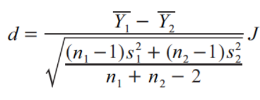

## No R

- Vamos carregar um conjunto de dados e dar uma olhada nele.

```r
dados <- read.csv(file = "../98 - dados para exemplos/medias.csv", header = TRUE)
str(dados)
```

```
## 'data.frame':    16 obs. of  11 variables:
##  $ estudo            : int  11 3 10 4 6 9 2 11 5 7 ...
##  $ autor             : Factor w/ 11 levels "Aline","Ana",..: 11 3 10 4 6 9 2 11 5 7 ...
##  $ riqueza_controle  : int  1 1 1 1 1 1 1 1 1 1 ...
##  $ riqueza_tratamento: int  3 4 4 5 5 5 5 6 6 7 ...
##  $ ecossistema       : Factor w/ 2 levels "Aquatico","Terrestre": 2 1 1 1 2 2 1 1 1 2 ...
##  $ media_controle    : num  2.71 2.28 2.69 3.2 3.15 ...
##  $ sd_controle       : num  0.336 1.615 0.77 0.655 1.204 ...
##  $ n_controle        : int  9 9 9 7 7 7 7 7 7 7 ...
##  $ media_tratamento  : num  1.34 1.54 1.61 2.11 2.77 ...
##  $ sd_tratamento     : num  1.34 2.62 1.77 1.66 2.2 ...
##  $ n_tratamento      : int  9 9 9 7 7 7 7 7 7 7 ...
```

## No R

- Utilizaremos o pacote `metafor` para realizar todas as tarefas relacionadas à meta-análise.
- Vamos calcular o valor de *d* para cada estudo neste conjunto de dados com o `escalc`.
- `SMD` especifica o calculo de *d*: **S**tandardized **M**ean **D**ifference.
- Incorpora a correção para amostras pequenas.

```r
library(metafor)
escalc(measure = "SMD", # opcao de metrica do tamanho do efeito
       m1i = media_tratamento, sd1i = sd_tratamento, n1i = n_tratamento, # infos do tratamento
       m2i = media_controle, sd2i = sd_controle, n2i = n_controle, # infos do controle
       data = dados) # conjunto de dados de onde extrair as informacoes acima
```

## No R

- O R vai automaticamente adicionar duas colunas ao conjunto de dados de onde ele extraiu as informações para o calculo do effect size:
  - `yi` representa a medida do tamanho do efeito em cada observação, que, nesse caso, é o valor de *d* (diferença entre médias em unidades de desvio padrão); e,
  - `vi` representa a estimativa da variância da estimativa do tamanho do efeito em cada observação.

```
##    estudo     autor riqueza_tratamento      yi     vi
## 1      11     Maria                  3 -1.3334 0.2716
## 2       3   Antonio                  4 -0.3242 0.2251
## 3      10    Marcos                  4 -0.7577 0.2382
## 4       4  Fernanda                  5 -0.8046 0.3088
## 5       6      Joao                  5 -0.2034 0.2872
## 6       9    Marcia                  5 -0.6654 0.3015
## 7       2       Ana                  5  1.8936 0.4138
## 8      11     Maria                  6  1.6277 0.3803
## 9       5 Francisca                  6  1.7914 0.4003
## 10      7      Jose                  7  0.5054 0.2948
## 11      8     Lucas                  8  1.3836 0.3541
## 12     11     Maria                  8  2.1690 0.5294
## 13      1     Aline                  9  1.3707 0.4939
## 14      2       Ana                  9  1.3479 0.4908
## 15      7      Jose                 10  2.4570 0.8773
## 16     11     Maria                 10  2.2624 0.8199
```

## No R

- Utilizamos também o `escalc` para calcular o LRR, especificando `ROM` como a medida do tamanho do efeito: **R**atio **o**f **M**eans.
- O resultado pode ser expresso em %, caso você tire o exponencial do LRR.

```r
escalc(measure = "ROM", m1i = media_tratamento, sd1i = sd_tratamento, n1i = n_tratamento,
       m2i = media_controle, sd2i = sd_controle, n2i = n_controle, data = dados)
```

```
##    estudo     autor riqueza_tratamento      yi     vi
## 1      11     Maria                  3 -0.7009 0.1117
## 2       3   Antonio                  4 -0.3916 0.3743
## 3      10    Marcos                  4 -0.5165 0.1441
## 4       4  Fernanda                  5 -0.4133 0.0936
## 5       6      Joao                  5 -0.1306 0.1115
## 6       9    Marcia                  5 -0.3675 0.0981
## 7       2       Ana                  5  0.5922 0.0151
## 8      11     Maria                  6  0.7044 0.0332
## 9       5 Francisca                  6  1.0501 0.0857
## 10      7      Jose                  7  0.2085 0.0390
## 11      8     Lucas                  8  0.5702 0.0354
## 12     11     Maria                  8  1.1063 0.0714
## 13      1     Aline                  9  0.5692 0.0473
## 14      2       Ana                  9  0.5741 0.0502
## 15      7      Jose                 10  1.4969 0.2425
## 16     11     Maria                 10  1.0664 0.0978
```

## No R

- No `escalc`, `COR` especifica o calculo do effect size baseado no valor bruto da correlação, enquanto `ZCOR` o faz baseado no valor do coeficiente de correlção transformado.
- A estimativa da variância não é afetada, uma vez que seu calculo não depende do valor de *r*.

```r
dados <- read.csv(file = "../98 - dados para exemplos/correlacao.csv")
escalc(measure = "ZCOR", ri = r, ni = n, data = dados)
```

```
##    estudo     autor riqueza_tratamento      r  n     yi     vi
## 1      11     Maria                  3 0.1691 12 0.1707 0.1111
## 2       3   Antonio                  4 0.2126 10 0.2159 0.1429
## 3      10    Marcos                  4 0.2433 10 0.2483 0.1429
## 4       4  Fernanda                  5 0.1981 10 0.2008 0.1429
## 5       6      Joao                  5 0.2981 10 0.3074 0.1429
## 6       9    Marcia                  5 0.2941  7 0.3030 0.2500
## 7       2       Ana                  5 0.3581 10 0.3747 0.1429
## 8      11     Maria                  6 0.4120 12 0.4380 0.1111
## 9       5 Francisca                  6 0.3436  9 0.3582 0.1667
## 10      7      Jose                  7 0.4762 10 0.5181 0.1429
## 11      8     Lucas                  8 0.3856 10 0.4066 0.1429
## 12     11     Maria                  8 0.3728 10 0.3917 0.1429
## 13      1     Aline                  9 0.4021  7 0.4262 0.2500
## 14      2       Ana                  9 0.4515 12 0.4866 0.1111
## 15      7      Jose                 10 0.5751  8 0.6551 0.2000
## 16     11     Maria                 10 0.5347  8 0.5967 0.2000
```

## Slopes

- Outra medida relevante que pode ser usada como *effect size*;
- Mede a taxa de mudança em um variável dependente de acordo com uma variável independente;
- O valor do effect size é o slope em si, e o valor da variância é o valor do erro associado ao slope, elevado ao quadrado (ver Capítulo 6 do livro de Meta-análise para detalhes);
- Muito cuidado deve ser tomado quando usar esta métrica, pois:
  1. Ela se baseia no pressuposto de linearidade;
  2. Pressupõem que não haja problemas com dados aberrantes;
  3. Quando em um contexto de regressão múltipla, valor do *slope* não é o mesmo do quando quando em uma regressão simples.
- No R (ou qualquer outro programa estatístico), este valor é representado pelo `estimate` em uma análise;

## Outras Métricas

- Em essência, qualquer estimativa de um dado efeito pode ser usada para o cálculo do *effect size*;
- Existem diversas outras métricas disponíveis:
  - Odds Ratio: define a razão entre a chance de um evento ocorrer em um grupo *vs* em um segundo grupo;
  - Incidence Rate Ratio: razão entre o número de eventos específicos e o número total de eventos em uma população;
  - Estimativas de Padrões: valores que descrevam algum padrão/processo ecológico (emissão de um gás, densidade de plantas em áreas alagadas de um determinado tipo,…).

## Um exemplo para estimativas de padrões

- Emissão de gases a partir de diferentes tipos de ecossistemas aquáticos.

```r
dados <- read.csv(file = "../98 - dados para exemplos/emissao.csv", header = TRUE)
escalc(measure = "MN", mi = emissao, sdi = desvio, ni = replicas, data = dados)
```

```
##    estudo     autor ecossistema emissao desvio replicas       yi       vi
## 1      11     Maria      riacho     283 52.238       13 283.0000 209.9084
## 2       3   Antonio      riacho     292 79.927       26 292.0000 245.7048
## 3      10    Marcos      riacho     280 74.245       18 280.0000 306.2400
## 4       4  Fernanda      riacho     305 41.921       17 305.0000 103.3747
## 5       6      Joao      riacho     300 41.366       22 300.0000  77.7794
## 6       9    Marcia       lagos     772 72.388       22 772.0000 238.1828
## 7       2       Ana       lagos     787 44.128       12 787.0000 162.2734
## 8      11     Maria       lagos     767 65.880       16 767.0000 271.2609
## 9       5 Francisca       lagos     809 49.803       22 809.0000 112.7427
## 10      7      Jose       lagos     800 58.733       23 800.0000 149.9811
## 11      8     Lucas       lagos     804 46.219       20 804.0000 106.8098
## 12     11     Maria       pocas     478 51.971       20 478.0000 135.0492
## 13      1     Aline       pocas     490 67.438       21 490.0000 216.5659
## 14      2       Ana       pocas     474 32.341       21 474.0000  49.8067
## 15      7      Jose       pocas     507 39.897       27 507.0000  58.9545
## 16     11     Maria       pocas     500 70.588       27 500.0000 184.5432
```

## Transformando entre métricas

- Alguns estudos podem não te fornecer os valores de média, coeficientes de correlação, slopes e estimativas de erro de forma direta.
- Uma das opções é realizar conversões baseadas nos dados que estão disponíveis (lista completa no Capítulo 13 do livro de Meta-Análise):
  - t para *d*
  - *r* para *d* (e vice-versa)
  - F para *d*
  - *z* para *d* (e vice-versa)
  - \(\chi\)<sup>2</sup> para *d*
  - Slope para *r* (e vice-versa)
  - t para *r*
  - F para *r*
  - *z* para *r* (e vice-versa)
  - \(\chi\)<sup>2</sup> para *r*
  - *t* para *z*

## Resumindo

- Em qualquer trabalho que fizemos, é importante considerar tanto o tamanho do efeito do que estamos medindo, quanto a incerteza existente nesta estimativa.
- Este tipo de pensamento é essencial para passarmos uma estatística frequentista baseada em uma única hipótese, para aquela que contempla múltiplas hipóteses igualmente válidas.
- Em uma meta-análise, é essencial calcularmos ou extrairmos uma métrica de tamanho de efeito e também a sua variância, para que o peso de cada estudo seja proporcional à sua precisão.
- Existem vários tipos de métricas de effect size, mas a escolha de qual delas usar depende em grande parte da sua pergunta.
- Alguns métodos específicos existem para lidar para o cálculo de effect size e sua variância quando houverem dados faltantes ou incompletos.

## Literatura Recomendada

1. Nakagawa & Cuthill, 2007, Biol Rev, Effect size, confidence interval and statistical significance - a practical guide for biologists
2. Lajeunesse, 2015, Ecology, Bias and correction for the log response ratio in ecological meta-analysis
3. Rosenberg et al, 2013, Effect Sizes: Conventional choices and calculations, In: Handbook of meta-analysis in ecology and evolution (Capítulo 6)
4. Mengersen & Gurevitch, 2013, Using other metrics of effect size in meta-analysis, In: Handbook of meta-analysis in ecology and evolution (Capítulo 7)
5. Lajeunesse, 2013, Recovering missing or partial data from studies: a survey of conversions and imputations for meta-analysis, In: Handbook of meta-analysis in ecology and evolution (Capítulo 13)